# Spatial Extrapolation of Migration Direction

Oleksii Dubovyk

5/24/2021

Let `pool` be a regular grid of points we will use for extrapolation and `points` be the observation of migrating objects or meteorological stations collecting the data on wind direction. Thus, `points` objects own coordinates `x` and `y` (or `longitude` and `latitude` respectively) and some value of direction (in degrees so that 0° is North, 180° is South, etc. - see the figure).

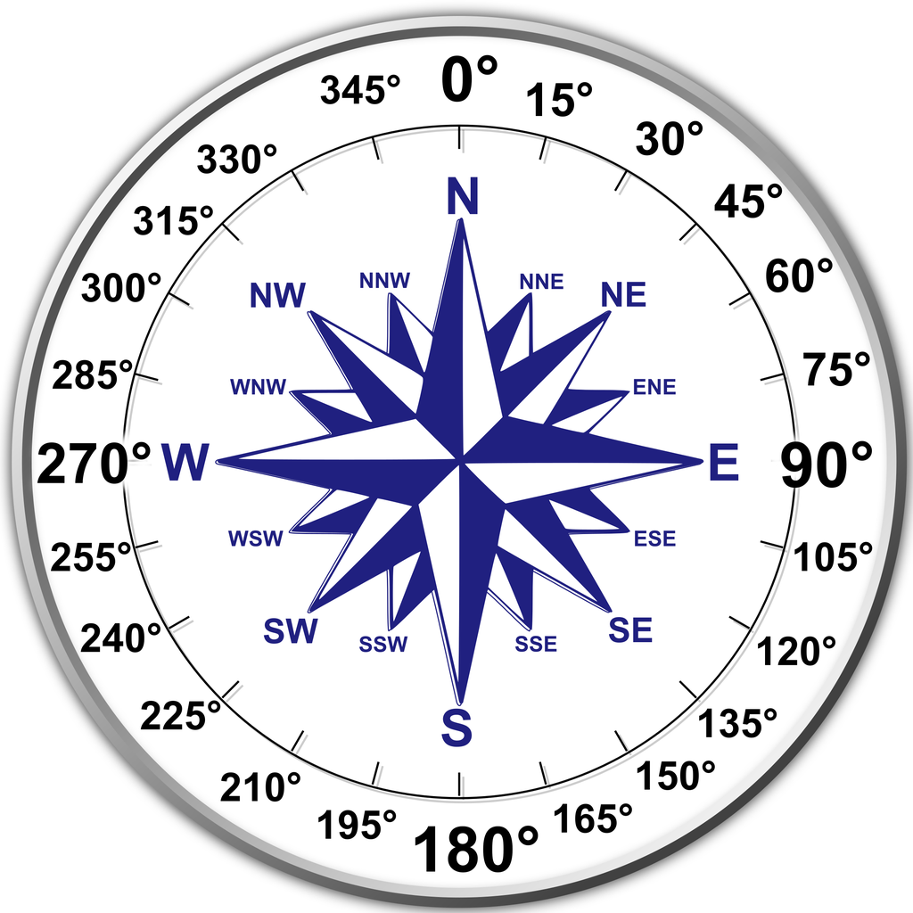

The `pool` objects, instead, own their coordinated only, and we want to add some direction value to them.

For example,

```r
pool <- data.frame(x = c(1,1,1,1,2,2,2,2,3,3,3,3,4,4,4,4), y = c(1,2,3,4,1,2,3,4,1,2,3,4,1,2,3,4))
pool
```

```
##    x y
## 1  1 1
## 2  1 2
## 3  1 3
## 4  1 4
## 5  2 1
## 6  2 2
## 7  2 3
## 8  2 4
## 9  3 1
## 10 3 2
## 11 3 3
## 12 3 4
## 13 4 1
## 14 4 2
## 15 4 3
## 16 4 4
```

```r
points <- data.frame(x = c(1,3,2), y = c(1,3,2), direction = c(0, 180, 315))
points
```

```
##   x y direction
## 1 1 1         0
## 2 3 3       180
## 3 2 2       315
```

To visualize that, we need firstly to define some useful functions, namely

- to transform degrees into radians

```r
deg2rad <- function(x) {
  x * pi/180
}
```

- to transform radians into degrees

```r
rad2deg <- function(x) {
  x * 180/pi
}
```

- besides, calculating an average degree is complicated: since 180° = 540° = -180°, arithmetic mean should not be used for this case; 2-argument arctangent function `atan2` should be used instead[^1] (see also Wikipedia[^2]):

$\overline{\alpha} = atan2(\frac{1}{n}\sum_{i=1}^{n}\sin(\alpha_i), \frac{1}{n}\sum_{i=1}^{n}\cos(\alpha_i))$

So we can visualize the above mentioned and already defined objects `pool` and `points`:

```r
draw.arrows <- function(data, col = "black"){
  for (i in 1:nrow(data)){
  arrows(x0 = data[i, 1], y0 = data[i, 2],
         x1 = data[i, 1] + sin(deg2rad(data[i, 3])),
         y1 = data[i, 2] + cos(deg2rad(data[i, 3])),
         col = col)
}
}
```

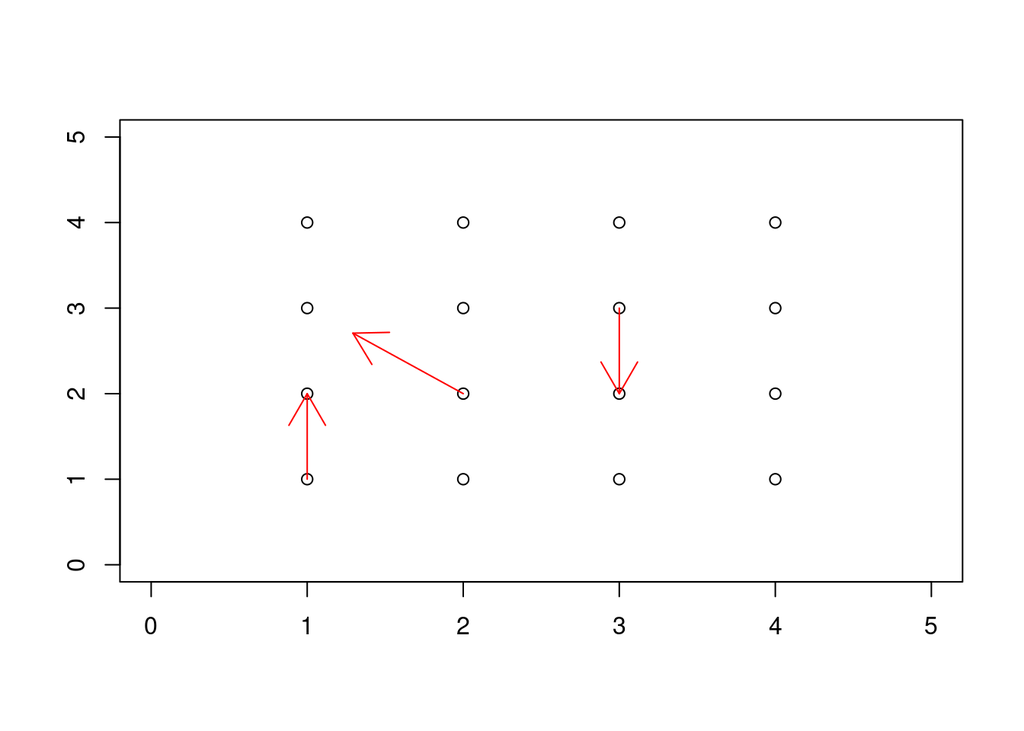

```r
plot(pool$x, pool$y, xlim = c(0, 5), ylim = c(0, 5), xlab = "", ylab = "")
draw.arrows(points, col = "red")
```

Thus, our task is to extrapolate the direction of the red arrows to every black point within `pool`. It is possible to do this via taking a weighted average of directions of every red arrow. Weight, in this case, has to be inversely proportional to a distance between a focal point of the `pool` and an arrow:

$\overline{\alpha} = atan2(\sum_{i=1}^{n}w_i\sin(\alpha_i),\sum_{i=1}^{n}w_i\cos(\alpha_i))$

so that $\sum_{i=1}^{n}w_i=1$.

Firstly, we need to define a function for weighted atan2 circular average.

```r
weighted_atan2 <- function(degrees, weights = rep(1/length(degrees), length(degrees))){
  if (sum(weights) > 1.05 | sum(weights) < 0.95) stop("sum of weights is not 1")
  deg2rad <- function(x) x * pi/180
  rad2deg <- function(x) x * 180/pi
  weighted <- data.frame(sines = sin(deg2rad(degrees)),
                         cosines = cos(deg2rad(degrees)),
                         weights = weights)
  rad2deg(atan2(y = sum(weighted$sines * weighted$weights),
                x = sum(weighted$cosines * weighted$weights)))
}
```

For example, averages of (0°, 180°, 90°) should be the same as (360°, 540°, 90°):

```r
weighted_atan2(c(0, 180, 90))
```

```
## [1] 90
```

```r
weighted_atan2(c(360, 540, 90))
```

```
## [1] 90
```

Note that by default, the average is not weighted, i.e. $w_i = \frac{1}{n}$.

Now we shall define a function to return the extrapolated values for every point of the `pool`:

```r
weighted.degree <- function(pool, points){
  euclidian.dist <- function(x1, y1, x2, y2) sqrt((x1-x2)^2+(y1-y2)^2)
  distances <- matrix(NA, nrow = nrow(pool), ncol = nrow(points))
  for (i in 1:nrow(pool)){
    for (j in 1:nrow(points)){
      distances[i, j] <- euclidian.dist(pool[i,1], pool[i,2],
                                        points[j,1], points[j,2])
    }
  }
  distances <- as.data.frame(distances)
  distances <- as.data.frame(t(apply(distances, 1, function(x) 1-x/sum(x))))
  distances <- as.data.frame(t(apply(distances, 1, function(x) x/sum(x))))
  averages <- rep(NA, nrow(pool))
  for(i in 1:nrow(pool)){
    averages[i] <- weighted_atan2(points[,3], as.numeric(distances[i,]))
  }
  cbind(pool, averages)
}
```

and use it for our test data:

```r
test <- weighted.degree(pool = pool, points = points)
test
```

```
##    x y   averages
## 1  1 1  -22.50000
## 2  1 2  -32.99462
## 3  1 3  -45.00000
## 4  1 4  -51.56206
## 5  2 1  -32.99462
## 6  2 2  -45.00000
## 7  2 3  -65.30615
## 8  2 4  -65.30615
## 9  3 1  -45.00000
## 10 3 2  -65.30615
## 11 3 3 -112.50000
## 12 3 4  -78.69443
## 13 4 1  -51.56206
## 14 4 2  -65.30615
## 15 4 3  -78.69443
## 16 4 4  -73.67505
```

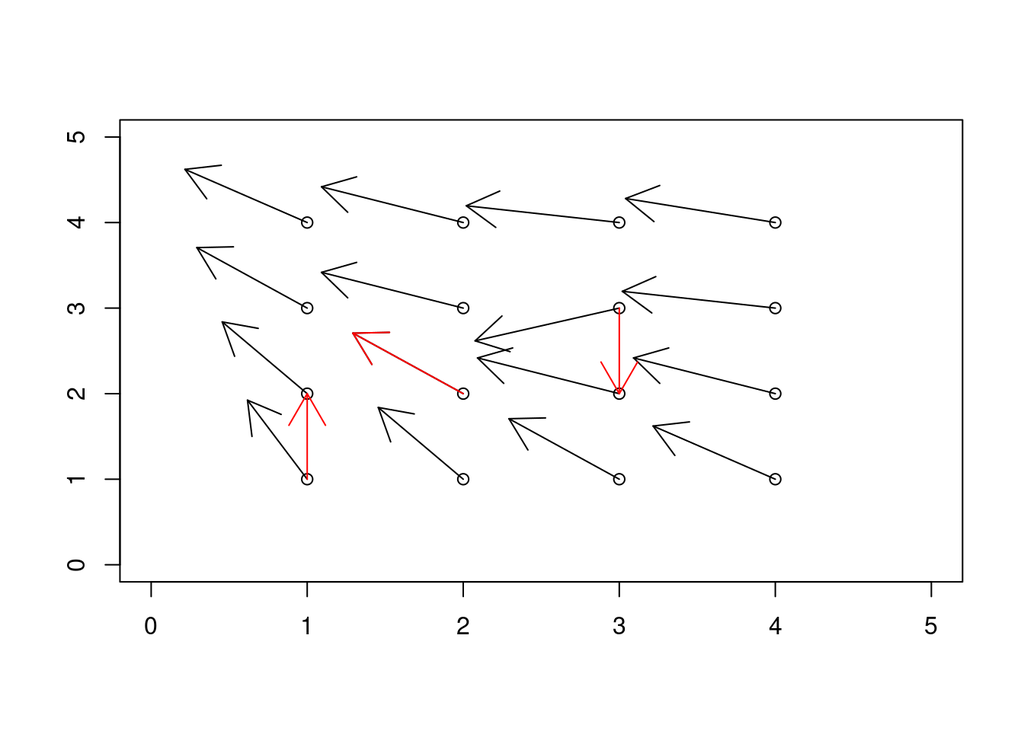

```r
plot(test$x, test$y, xlim = c(0, 5), ylim = c(0, 5), xlab = "", ylab = "")
draw.arrows(test, col = "black")
draw.arrows(points, col = "red")
```

```r
weighted2_atan2 <- function(degrees, weights1, weights2){
  deg2rad <- function(x) x * pi/180
  rad2deg <- function(x) x * 180/pi
  weights <- weights1*weights2
  weights <- sapply(weights, function(x) x/sum(weights))
  weighted <- data.frame(sines = sin(deg2rad(degrees)),
                         cosines = cos(deg2rad(degrees)),
                         weights = weights)
  rad2deg(atan2(y = sum(weighted$sines * weighted$weights),
                x = sum(weighted$cosines * weighted$weights)))
}
```

```r
weighted.degree2 <- function(pool, points){
  euclidian.dist <- function(x1, y1, x2, y2) sqrt((x1-x2)^2+(y1-y2)^2)
  distances <- matrix(NA, nrow = nrow(pool), ncol = nrow(points))
  for (i in 1:nrow(pool)){
    for (j in 1:nrow(points)){
      distances[i, j] <- euclidian.dist(pool[i,1], pool[i,2],
                                        points[j,1], points[j,2])
    }
  }
  distances <- as.data.frame(distances)
  distances <- as.data.frame(t(apply(distances, 1, function(x) 1-x/sum(x))))
  distances <- as.data.frame(t(apply(distances, 1, function(x) x/sum(x))))
  averages <- rep(NA, nrow(pool))
  for(i in 1:nrow(pool)){
    averages[i] <- weighted2_atan2(points[,3], as.numeric(distances[i,]), points[,4])
  }
  cbind(pool, averages)
}
```

```r
points2 <- data.frame(x = c(1,3,2), y = c(1,3,2), direction = c(0, 180, 315), ind = c(1, 30, 5))
points2
```

```
##   x y direction ind
## 1 1 1         0   1
## 2 3 3       180  30
## 3 2 2       315   5
```

```r
test2 <- weighted.degree2(pool = pool, points = points2)
```

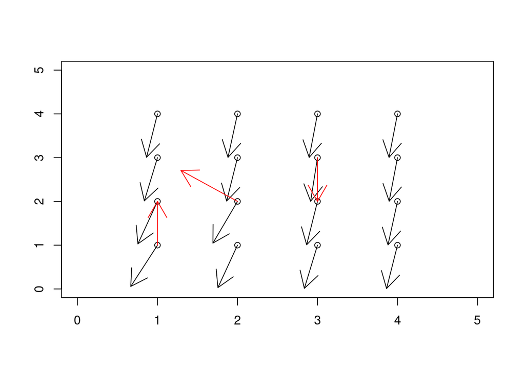

```r
plot(test2$x, test2$y, xlim = c(0, 5), ylim = c(0, 5), xlab = "", ylab = "")
draw.arrows(test2, col = "black")
draw.arrows(points, col = "red")
```

Besides, for a big massif of points it is possible to define a limit of weighting: if a focal point of the pool is too far from an pbservation point, then the weight of this point is automatically zero.

```r
weighted.degree2.lim <- function(pool, points, limit){
  euclidian.dist <- function(x1, y1, x2, y2) sqrt((x1-x2)^2+(y1-y2)^2)
  distances <- matrix(NA, nrow = nrow(pool), ncol = nrow(points))
  for (i in 1:nrow(pool)){
    for (j in 1:nrow(points)){
      distances[i, j] <- euclidian.dist(pool[i,1], pool[i,2],
                                        points[j,1], points[j,2])
    }
  }
  distances <- as.data.frame(distances)
  distances <- as.data.frame(t(apply(distances, 1, function(x) ifelse(x > limit, 0, 1-x/sum(x)))))
  distances <- as.data.frame(t(apply(distances, 1, function(x) x/sum(x))))
  averages <- rep(NA, nrow(pool))
  for(i in 1:nrow(pool)){
    averages[i] <- weighted2_atan2(points[,3], as.numeric(distances[i,]), points[,4])
  }
  cbind(pool, averages)
}
```

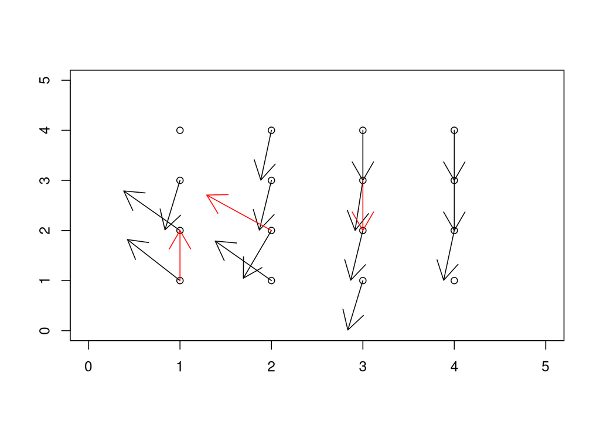

```r
test3 <- weighted.degree2.lim(pool = pool, points = points2, limit = 2)
plot(test3$x, test3$y, xlim = c(0, 5), ylim = c(0, 5), xlab = "", ylab = "")
draw.arrows(test3, col = "black")
draw.arrows(points, col = "red")
```

Note that the points `(1, 4)` and `(4, 1)` are too far (> 2.0) from any of the red arrows so that their directions remain unknown.

Thus, for extrapolation in the described way one would use two data frames:

- a two-column table of coordinates of points within a regular (or any other) grid
- a 3- or 4- column table of observations: x- and y- coordinates, direction, and optional additional weight.
[^1]: Christopher M. Bishop: Pattern Recognition and Machine Learning (Information Science and Statistics), ISBN 0-387-31073-8
[^2]: Mean of circular quantities. https://en.wikipedia.org/wiki/Mean_of_circular_quantities